# Regression tutorial

Yusuf Tatlier

Goal of regression is to explain the the variation in the dependent variable y (also known as the response), by the variation in one or multiple independent variables (also known as the explanatory variable/covariate/regressor).

The main idea that we use in this tutorial is that we generate our own data and then use regression to estimate the coefficients of the regression.

## Simple Linear Regression

```r
require(moments)

set.seed(1001)
x<-seq(0,10,0.025)
y<-1.2+2.4*x+rnorm(length(x))
slr<-lm(y~x)
summary(slr) #Note variable is highly significant
```

```
##
## Call:
## lm(formula = y ~ x)
##
## Residuals:
##     Min      1Q  Median      3Q     Max
## -2.5532 -0.6935 -0.0447  0.6161  3.6173
##
## Coefficients:
##             Estimate Std. Error t value Pr(>|t|)
## (Intercept)  1.20772    0.10061    12.0   <2e-16 ***
## x            2.40021    0.01742   137.8   <2e-16 ***
## ---
## Signif. codes:  0 '***' 0.001 '**' 0.01 '*' 0.05 '.' 0.1 ' ' 1
##
## Residual standard error: 1.009 on 399 degrees of freedom
## Multiple R-squared:  0.9794, Adjusted R-squared:  0.9794
## F-statistic: 1.899e+04 on 1 and 399 DF,  p-value: < 2.2e-16
```

```r
coef_1<-coef(summary(slr))[1]
coef_2<-coef(summary(slr))[2]
coef(summary(slr))[2,]  #Also provides standard error, t statistic and p value
```

```
##     Estimate   Std. Error      t value     Pr(>|t|)
##   2.40020591   0.01741581 137.81762832   0.00000000
```

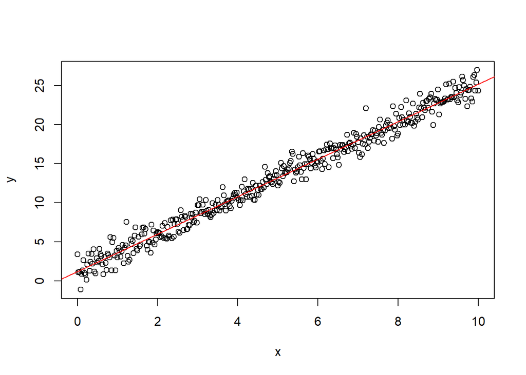

```r
plot(x,y)
abline(slr,col="red")
```

```r
#Plotting residuals
hist(slr$residuals,breaks = 50, main="residuals")

#Testing on normality: Both tests don't reject the null hypothesis of normality
require("moments")
jarque.test(slr$residuals)
```

```
##
##  Jarque-Bera Normality Test
##
## data:  slr$residuals
## JB = 5.6836, p-value = 0.05832
## alternative hypothesis: greater
```

```r
shapiro.test(slr$residuals)
```

```
##
##  Shapiro-Wilk normality test
##
## data:  slr$residuals
## W = 0.99351, p-value = 0.08253
```

```r
#Estimate variance
sd(slr$residuals)
```

```
## [1] 1.00801
```

```r
#You can also use:
require(fitdistrplus)
```

[figure not shown]

```r
norm_fit<-fitdist(slr$residuals,"norm")
print(norm_fit)
```

```
## Fitting of the distribution ' norm ' by maximum likelihood
## Parameters:
##           estimate Std. Error
## mean -2.550130e-16 0.05027481
## sd    1.006752e+00 0.03554950
```

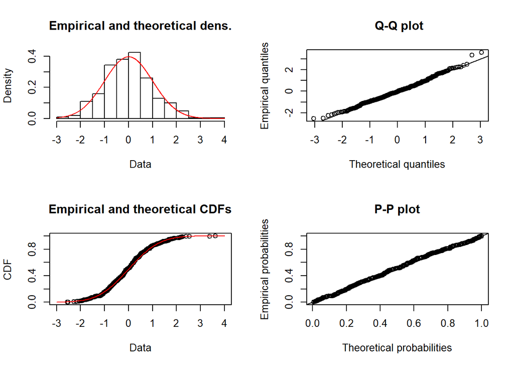

```r
#The package has some plotting tools
plot(norm_fit)
```

```r
#Ideally the  residuals should follow a normal distribution around zero as this indicates the model contains all information present in the data. If this is not the case, it is advisable to evaluate the model and possibly add some components.

cat("b estimator can also be obtained as:",cov(x,y)/var(x))
```

```
## b estimator can also be obtained as: 2.400206
```

```r
cat("a estimator can also be obtained as:",mean(y)-(cov(x,y)/var(x))*mean(x))
```

```
## a estimator can also be obtained as: 1.207724
```

```r
cat("b has a normal distribution with variance:",cov(x,y)/var(x))
```

```
## b has a normal distribution with variance: 2.400206
```

```r
cat("Coeffcient of determination is given by:",summary(slr)$r.squared)
```

```
## Coeffcient of determination is given by: 0.9794252
```

```r
cat("Adjusted coeffcient of determination is given by:",summary(slr)$adj.r.squared) #Same as only one explanatory variable is present
```

```
## Adjusted coeffcient of determination is given by: 0.9793737
```

A different way to look at the fit of the data is an analysis of variance analsis (ANOVA). This analysis shows how much variation is explained by the introduction of an explanatory variable.

```r
sum((y-mean(y))^2)
```

```
## [1] 19753.99
```

```r
anova(slr)
```

```
## Analysis of Variance Table
##
## Response: y
##            Df  Sum Sq Mean Sq F value    Pr(>F)
## x           1 19347.6   19348   18994 < 2.2e-16 ***
## Residuals 399   406.4       1
## ---
## Signif. codes:  0 '***' 0.001 '**' 0.01 '*' 0.05 '.' 0.1 ' ' 1
```

```r
paste("The explanatory variable explains",round((anova(slr)[1,2]-anova(slr)[2,2])/anova(slr)[1,2],2)*100,"% of the variation in the variable y")
```

```
## [1] "The explanatory variable explains 98 % of the variation in the variable y"
```

Regressions can be seen as a varying distribution around a certain mean, which is the regression line. Look for example at the simple example of a regression with one dummy predictor.

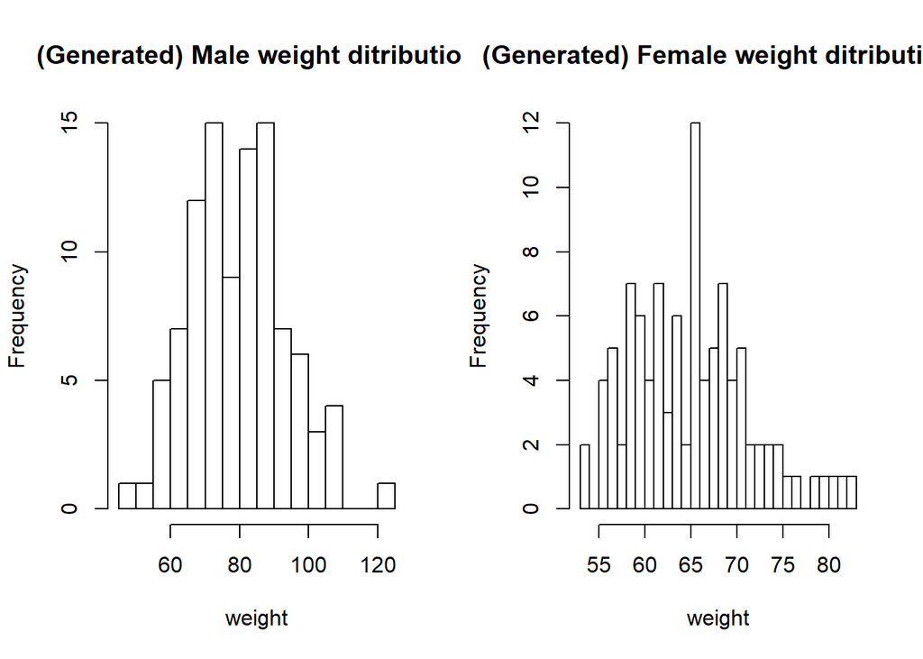

```r
#Generate data
set.seed(1001)
weight_men<-rnorm(100,80,12)
weight_women<-rnorm(100,65,8)
df_men<-data.frame(weight=weight_men,ind=1)
df_women<-data.frame(weight=weight_women,ind=0)

#Rbind the two datasets
df_weight<-rbind(df_men,df_women)

par(mfrow=c(1,2))
hist(df_weight[df_weight$ind==1,]$weight,breaks=25,main="(Generated) Male weight ditribution",xlab="weight")
hist(df_weight[df_weight$ind==0,]$weight,breaks=25,main="(Generated) Female weight ditribution",xlab="weight")
```

```r
weight_mod<-lm(weight~ind,data=df_weight)
summary(weight_mod)
```

```
##
## Call:
## lm(formula = weight ~ ind, data = df_weight)
##
## Residuals:
##     Min      1Q  Median      3Q     Max
## -30.068  -6.847   0.331   5.786  40.636
##
## Coefficients:
##             Estimate Std. Error t value Pr(>|t|)
## (Intercept)   65.049      1.072  60.662   <2e-16 ***
## ind           14.941      1.516   9.853   <2e-16 ***
## ---
## Signif. codes:  0 '***' 0.001 '**' 0.01 '*' 0.05 '.' 0.1 ' ' 1
##
## Residual standard error: 10.72 on 198 degrees of freedom
## Multiple R-squared:  0.329,  Adjusted R-squared:  0.3256
## F-statistic: 97.08 on 1 and 198 DF,  p-value: < 2.2e-16
```

```r
#Note that the difference in the mean weights is given by the coefficient ind.
#The OLS will not yield the sds of both classes as it assumes homogeneity, however note that the residual standard error lies between the sd of both classes.
```

## Multiple linear regression

```r
set.seed(1001)
mlr_reg_1<-seq(0,10,0.025)
mlr_reg_2<-seq(0,40,0.1)+rnorm(401,0,5)
mlr_res<-3+4*mlr_reg_1+1.2*mlr_reg_2+rnorm(length(mlr_reg_1))
mlr<-lm(mlr_res~mlr_reg_1+mlr_reg_2)

cat("Coeffcient of determination is given by:",summary(slr)$r.squared)
```

```
## Coeffcient of determination is given by: 0.9794252
```

```r
cat("Adjusted coeffcient of determination is given by:",summary(slr)$adj.r.squared)
```

```
## Adjusted coeffcient of determination is given by: 0.9793737
```

```r
anova(mlr)
```

```
## Analysis of Variance Table
##
## Response: mlr_res
##            Df Sum Sq Mean Sq F value    Pr(>F)
## mlr_reg_1   1 261028  261028  295679 < 2.2e-16 ***
## mlr_reg_2   1  14440   14440   16357 < 2.2e-16 ***
## Residuals 398    351       1
## ---
## Signif. codes:  0 '***' 0.001 '**' 0.01 '*' 0.05 '.' 0.1 ' ' 1
```

## Linear regression with a dummy term.

We show a regression with a dummy term.

```r
#Generate a dummy variable
x<-seq(0,1,1/400)+rnorm(401,0,0.2)
dummy_sec<-ifelse(x<0.5,0,2)
#Add to dependent variable
y<-1.2+2.4*x+dummy_sec+rnorm(401,0.3)

#linear regression
dlr<-lm(y~x+factor(dummy_sec))
summary(dlr)
```

```
##
## Call:
## lm(formula = y ~ x + factor(dummy_sec))
##
## Residuals:
##     Min      1Q  Median      3Q     Max
## -2.5071 -0.6784  0.0080  0.6829  3.2908
##
## Coefficients:
##                    Estimate Std. Error t value Pr(>|t|)
## (Intercept)         1.49563    0.09318  16.051  < 2e-16 ***
## x                   2.04896    0.26151   7.835 4.31e-14 ***
## factor(dummy_sec)2  2.27817    0.17923  12.711  < 2e-16 ***
## ---
## Signif. codes:  0 '***' 0.001 '**' 0.01 '*' 0.05 '.' 0.1 ' ' 1
##
## Residual standard error: 1.009 on 398 degrees of freedom
## Multiple R-squared:  0.755,  Adjusted R-squared:  0.7538
## F-statistic: 613.2 on 2 and 398 DF,  p-value: < 2.2e-16
```

## Interaction terms

In some cases there will be interaction terms between covariates, below it is shown how the coeffcients can be estimated in these cases. In case the interaction term is included it is customary to also include the separate covariates.

```r
set.seed(1001)
x1<-seq(0,1,length.out=500)+rnorm(500,0,0.2)
x2<-seq(0,5,length.out=500)+rnorm(500,0,0.5)
y<-2.4*x1+1.2*x2+0.2*x1*x2+rnorm(500)

#Estimate coefficients: Note that a large sample size is required for good estimates
lm(y~x1+x2+x1*x2-1)
```

```
##
## Call:
## lm(formula = y ~ x1 + x2 + x1 * x2 - 1)
##
## Coefficients:
##     x1      x2   x1:x2
## 1.6251  1.3295  0.2216
```

## Partialling out variables

In order to measure the ‘pure’ impact of a predictor or the response variable, indirect effects need to be partialled out.

```r
#Example of how partialling out works and that it makes and impact
require("isdals")
data(bodyfat)
attach(bodyfat)

#Note that Triceps and Thigh are good predictors of Fat on the basis of the strong positive
#correlatation, but they themselves are very strongly correlated.
cor(bodyfat)
```

```
##               Fat   Triceps     Thigh    Midarm
## Fat     1.0000000 0.8432654 0.8780896 0.1424440
## Triceps 0.8432654 1.0000000 0.9238425 0.4577772
## Thigh   0.8780896 0.9238425 1.0000000 0.0846675
## Midarm  0.1424440 0.4577772 0.0846675 1.0000000
```

```r
#The effect of Thigh on Thigh can be partialled out
mod_fat_thigh<-lm(Fat~Thigh)
mod_triceps_thigh<-lm(Triceps~Thigh)
part_cor_fat_triceps<-cor((predict(mod_fat_thigh)-Fat),(predict(mod_triceps_thigh)-Triceps))
paste("Partial correlation between fat and thigh variables is:",round(part_cor_fat_triceps,2))
```

```
## [1] "Partial correlation between fat and thigh variables is: 0.17"
```

## Violation of assumptions

We will have a look at how violations in the ordinary least squares assumptions affect the fit. If assumptions are violated it is advised to re-evalute the model (perform model iterations) and come with remedies. It is good to note that the residuals are the central quantities in these iterations that show potential model violations. Ideally one should obtain iid residuals with a normal distribution around zero, with constant variance, indicating a correct model specification and that all information in the data is incorporated into the model.

- Non-linearity

We have to make a distinction in two types of non-linearity here, namely non-linearity in regressors and non-linearity in the response variable. The linear relationship can be simply extended in order to capture non-linear relationships as long as it is still linear in the variables, see for example the polynomial regression below.

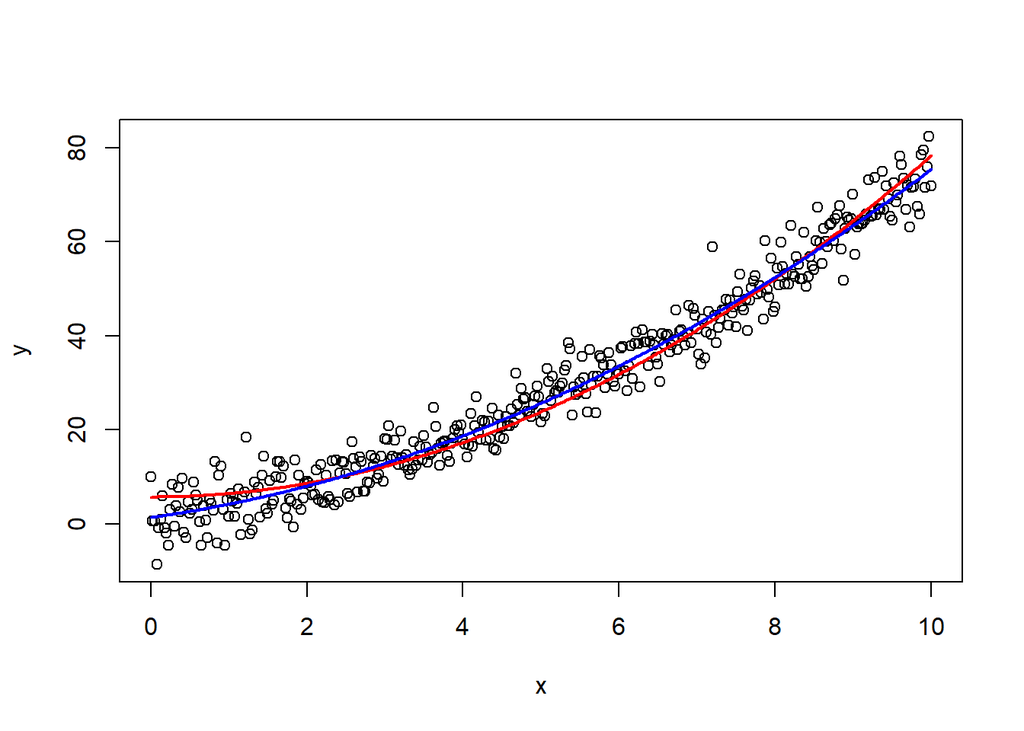

```r
set.seed(1001)
x<-seq(0,10,0.025)
y<-1.2+2.4*x+0.5*x^2+rnorm(length(x),0,4)
qlr_1<-lm(y~I(x^2))
qlr_2<-lm(y~x+I(x^2))
plot(x,y)
lines(x,fitted(qlr_1),col="red",lwd=2)
lines(x,fitted(qlr_2),col="blue",lwd=2)
```

Additionally also a transformation can be applied on the response variable $y$. The question arises in such a case how we can determine the most appropriate transformation. For this goal a Box-Cox (or power) transformation can be applied as seen below.

```r
set.seed(1001)
x<-seq(0,10,0.025)
y<-1.2+2.4*x+rnorm(length(x),0,1)
y_n<-y^4
bc_reg<-lm(y_n~x)
bc<-boxcox(bc_reg)
```

[figure not shown]

```r
#The maximum log-likelihood is obtained for close to lambda=0.25, note here that BC gives the power that needs to be applied to obtain the reverse situation.
bc$x[which.max(bc$y)]
```

```
## [1] 0.2626263
```

- Non-normality

Non-normality doesn’t necessarily need to be an issue as can be seen below. Note that a misspecified model can lead to the incorrect conclusion that the errors have a non-normal distribution.

```r
set.seed(1001)
x<-seq(0,10,0.025)

#An symmetrical distribution still gives unbiased OLS estimates, however the test quantities will be unreliable as they assume normality
y_t<-1.2+2.4*x+rt(length(x),5)
lr_t<-lm(y_t~x)
coef(summary(lr_t))
```

```
##             Estimate Std. Error    t value      Pr(>|t|)
## (Intercept) 1.319696 0.13316385   9.910319  7.632950e-21
## x           2.383244 0.02305025 103.393388 3.512811e-290
```

```r
norm_fit<-fitdist(lr_t$residuals,"norm")
print(norm_fit)
```

```
## Fitting of the distribution ' norm ' by maximum likelihood
## Parameters:
##          estimate Std. Error
## mean 1.220383e-16 0.06653994
## sd   1.332461e+00 0.04705072
```

```r
#Normality can be tested with for example the Jarque Bera test or the Shapiro Wilk test
#(Null hypothesis is that distribution is normal)
jarque.test(lr_t$residuals)
```

```
##
##  Jarque-Bera Normality Test
##
## data:  lr_t$residuals
## JB = 515.9, p-value < 2.2e-16
## alternative hypothesis: greater
```

```r
shapiro.test(lr_t$residuals)
```

```
##
##  Shapiro-Wilk normality test
##
## data:  lr_t$residuals
## W = 0.93964, p-value = 1.089e-11
```

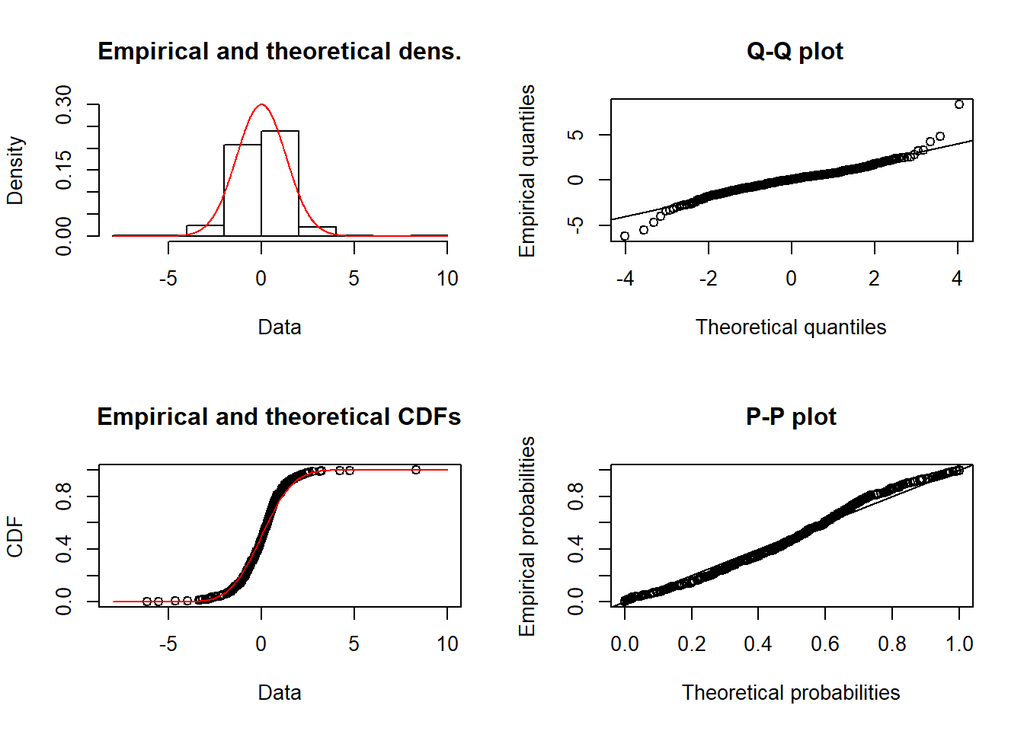

```r
#The package has some plotting tools
plot(norm_fit)
```

```r
#log-normal distribution is asymmetric (fat right tail) and leads to biased OLS estimates
y_ln<-1.2+2.4*x+rlnorm(length(x),0,1)
lr_ln<-lm(y_ln~x)
coef(summary(lr_ln))
```

```
##             Estimate Std. Error  t value      Pr(>|t|)
## (Intercept) 2.407479  0.2368528 10.16445  9.764998e-22
## x           2.495286  0.0409985 60.86287 4.983237e-204
```

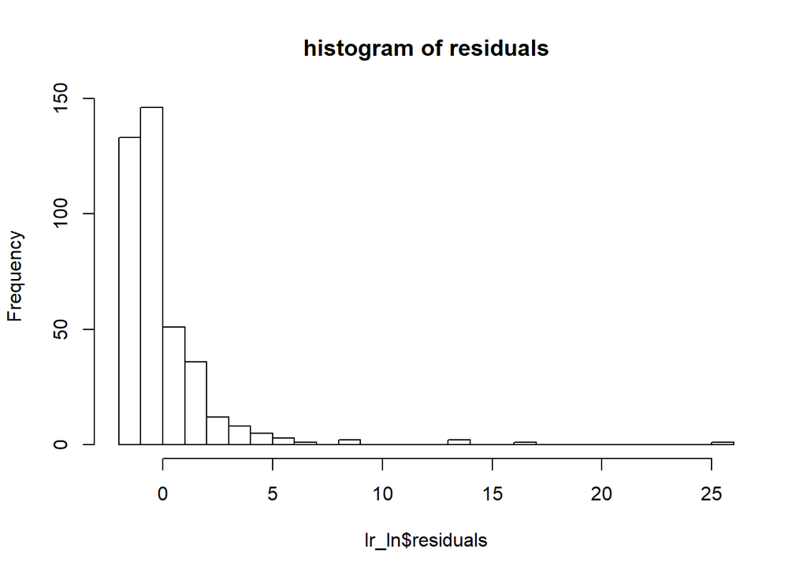

```r
hist(lr_ln$residuals,breaks=20,main="histogram of residuals")
```

- Outliers

It is important to identify outliers and appropriately clean data as this can have a large impact on (OLS) estimates.

```r
require(car)

set.seed(1001)
x<-seq(0,10,0.025)
y<-1.2+2.4*x+rnorm(length(x))

#Artificially generate outliers
y[100]=3*y[100]
y[200]=3*y[200]
y[300]=3*y[300]

#Regression
lr_outl<-lm(y~x)
coef(summary(lr_outl))
```

```
##             Estimate Std. Error   t value      Pr(>|t|)
## (Intercept) 1.329544 0.26527370  5.011969  8.114644e-07
## x           2.416051 0.04591806 52.616575 1.352942e-181
```

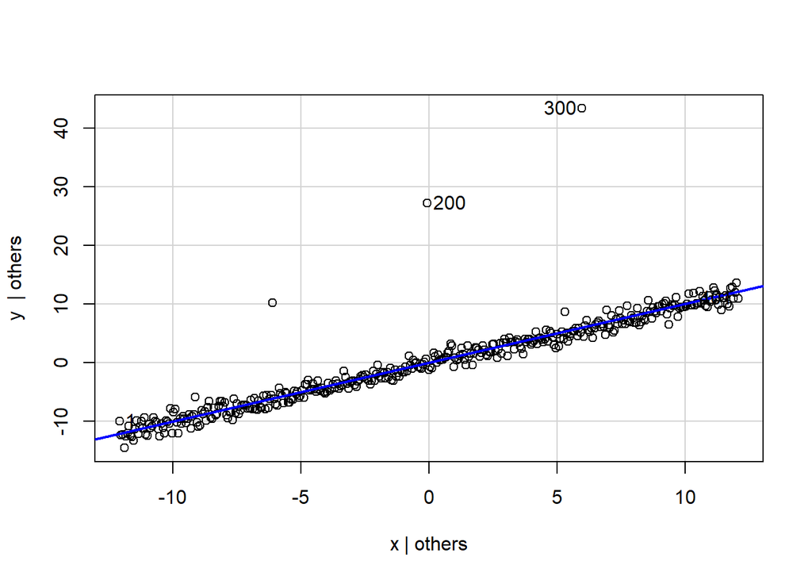

```r
#Leverage plots per regressor (1 in our case), gives the indices of suspected outliers
leveragePlots(lr_outl)
```

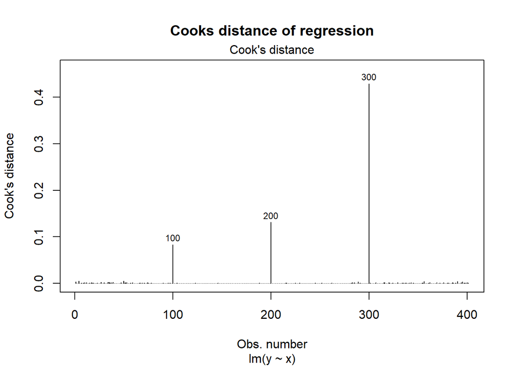

```r
#Detect outliers using Cooks distance
cutoff <- 4/((nrow(y)-length(coef(lr_outl))-2))
plot(lr_outl, which=4, cook.levels=cutoff,main="Cooks distance of regression")
```

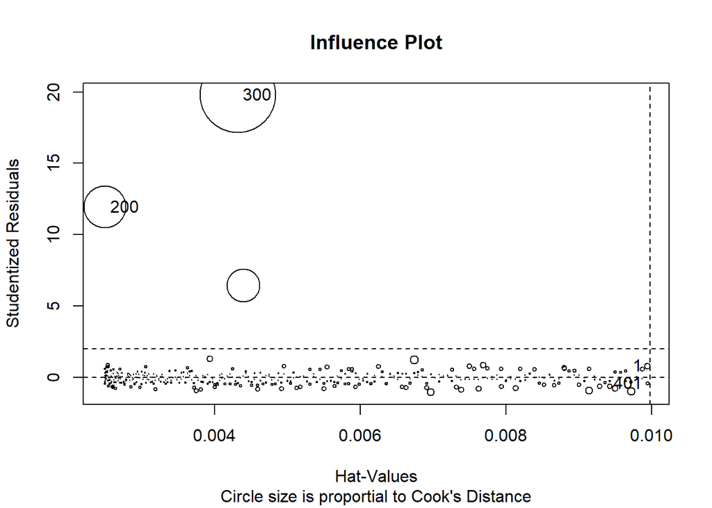

```
##        StudRes         Hat        CookD
## 1    0.7772907 0.009937842 0.0030352721
## 200 11.9206600 0.002493952 0.1312321089
## 300 19.7913696 0.004317750 0.4291115031
## 401 -0.4286429 0.009937842 0.0009240179
```

```r
# Influence Plot
influencePlot(lr_outl, main="Influence Plot", sub="Circle size is proportial to Cook's Distance" )
```

- Multicollinearity

We will see below that a strong correlation between regressors is a problem for the OLS method. The OLS estimate doesn’t exist in case of perfect multicollinearity while a strong positive correlation can lead to an increase in the standard deviation of the OLS estimates, reducing the power of the t-tests. The OLS estimates will still be unbiased. It needs to be noted that multicollinearity is a data related issue and removing removing regressors can lead to biased OLS estimates on the other hand, which is known as omitted variable bias.

```r
# In the regression that we have defined earlier, the regressors are strongly correlated.
cor(mlr_reg_1,mlr_reg_2)
```

```
## [1] 0.9170847
```

```r
#Another way to detect multicollinearity is with the use of so called Variance Inflation Factors (VIF). A VIF of 4 or larger is often used as rule for the presence of multicollinearity.
vif(mlr)
```

```
## mlr_reg_1 mlr_reg_2
##  6.291066  6.291066
```

```r
# Note that if we define the mlr_reg_2 (from the earlier multiple regression) in the following way, that the OLS regressor doesn't exist. This is because there is a perfect correlation between mlr_reg_1 and mlr_reg_2

set.seed(1001)
mlr_reg_2<-seq(0,40,0.1)
mlr_res<-3+4*mlr_reg_1+1.2*mlr_reg_2+rnorm(length(mlr_reg_1))
mlr<-lm(mlr_res~mlr_reg_1+mlr_reg_2)
cor(mlr_reg_1,mlr_reg_2)
```

```
## [1] 1
```

- Omitted variable bias and additional regressors

Below we will look at what happens if we remove or add regressors that are correlated with the response variable.

```r
# Note that if we want to remove a regressor that is (strongly) correlated with the response variable, ...
# The OLS estimate is biased.
mlr_1<-lm(mlr_res~mlr_reg_1)

# The opposite occurs if we add a regressor that is correlated with the response variable.
# Note that the standard deviation of the OLS estimates becomes larger as the correlation with the newly added regressor increases.
set.seed(2002)
mlr_new_1=mlr_res+rnorm(length(mlr_reg_2),0,1)
mlr_new_2=mlr_res+rnorm(length(mlr_reg_2),0,15)
cor(mlr_new_1,mlr_reg_2)
```

```
## [1] 0.9984867
```

```r
cor(mlr_new_2,mlr_reg_2)
```

```
## [1] 0.8670032
```

```r
mlr_2<-lm(mlr_res~mlr_reg_1+mlr_reg_2+mlr_new_1)
mlr_3<-lm(mlr_res~mlr_reg_1+mlr_reg_2+mlr_new_2)
coef(summary(mlr_2))
```

```
##              Estimate Std. Error  t value     Pr(>|t|)
## (Intercept) 1.3802881 0.10317267 13.37843 5.739947e-34
## mlr_reg_1   4.1985518 0.21719966 19.33038 3.440425e-59
## mlr_new_1   0.5241242 0.02470141 21.21840 2.196945e-67
```

```r
coef(summary(mlr_3))
```

```
##                Estimate  Std. Error     t value      Pr(>|t|)
## (Intercept) 2.999430739 0.101759876  29.4755739 4.171636e-102
## mlr_reg_1   8.783045423 0.034980085 251.0870199  0.000000e+00
## mlr_new_2   0.002008331 0.003549338   0.5658326  5.718265e-01
```

- Heteroskedasticity

```r
require("lmtest")
require("sandwich")
```

```r
set.seed(1001)
x<-seq(0.025,6,0.025)
y<-1.2+2.4*x+rnorm(length(x),0,x)
nonw_lm<-lm(y~x)

#The plot will often clearly show heteroskedasticity.
plot(x,y)

#Heteroskedasticity can be tested using various test. We will use the Breusch-Pagan test
#(Null hypothesis assumes homoskedasticity)
bptest(nonw_lm)
```

[output not shown]

```
##
##  studentized Breusch-Pagan test
##
## data:  nonw_lm
## BP = 39.715, df = 1, p-value = 2.938e-10
```

```r
#The problem with heteroskedasticity is that the OLS weighs all points equally while points with a smaller variance carry more information and should be weighted more heavily. There are various remedies.

# Making transformations, like taking the log of the dependent variable
log_model<-lm(log(y)~x)

#Robust estimators: As estimators are unbiased we can use robust standard errors in order to correct for heteroskedasticity in the hypothesis tests.
coeftest(nonw_lm, vcov = vcovHC(nonw_lm, "HC1"))
```

```
##
## t test of coefficients:
##
##             Estimate Std. Error t value  Pr(>|t|)
## (Intercept)  0.93072    0.27976  3.3269  0.001017 **
## x            2.54883    0.13377 19.0537 < 2.2e-16 ***
## ---
## Signif. codes:  0 '***' 0.001 '**' 0.01 '*' 0.05 '.' 0.1 ' ' 1
```

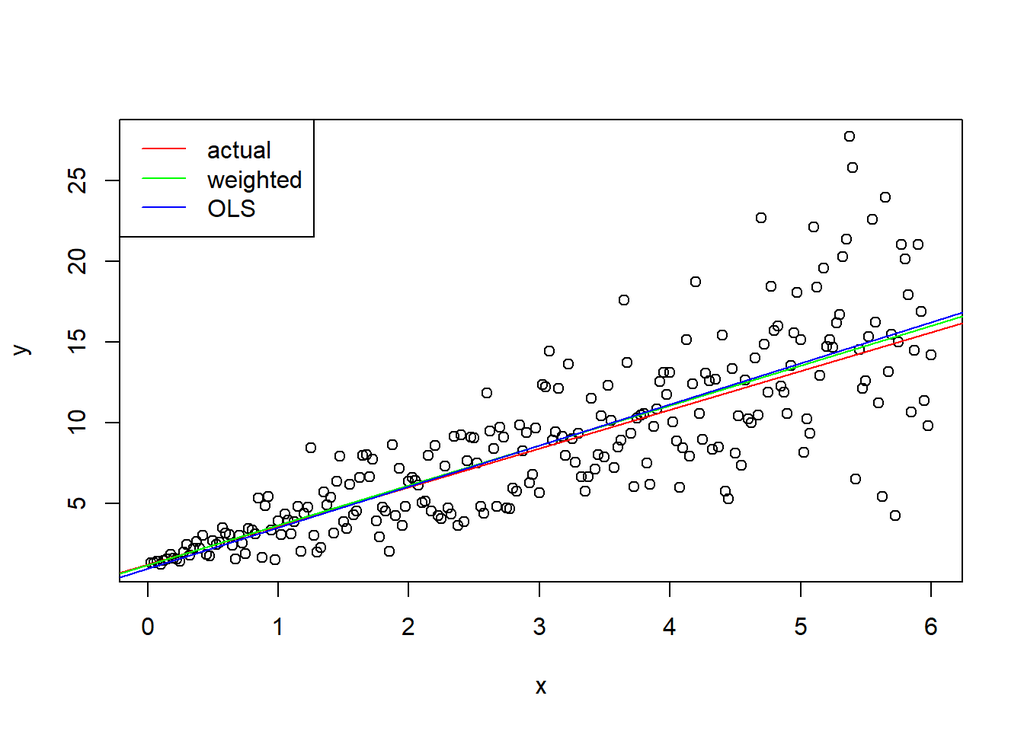

```r
#Weighted least squares (also called general least squares): address the issue of equally weighting all points by incorporating weights depending on the variance (this can be seen as a correction in order to obtain a homoskedastic situation).
w_lm<-lm(y~x,weights = 1/(0.2*x))

plot(x,y)
abline(a=1.2,b=2.4,col="red")
abline(w_lm,col="green")
abline(nonw_lm,col="blue")

legend("topleft",legend=c("actual","weighted","OLS"),col=c("red","green","blue"),lty=1)
```

```r
#Note the weighted least squares are closer to the actual coefficients
coef(summary(w_lm))
```

```
##             Estimate Std. Error  t value     Pr(>|t|)
## (Intercept) 1.164502 0.12511904  9.30715 8.989743e-18
## x           2.471230 0.07244665 34.11104 1.315205e-93
```

```r
coef(summary(nonw_lm))
```

```
##              Estimate Std. Error   t value    Pr(>|t|)
## (Intercept) 0.9307211  0.4061106  2.291792 2.27917e-02
## x           2.5488339  0.1168689 21.809346 1.11810e-58
```

- Autocorrelation

```r
set.seed(1001)
zt<-c(rnorm(1))

for(i in 2:200){
  zt[i]=0.96*zt[i-1]+rnorm(1)
}

x=1:200
y=1.2+1.8*x+zt

#Note that the OLS estimation yields unbiased estimates, however the test results can be unreliable
lr<-lm(y~x)
summary(lr)
```

```
##
## Call:
## lm(formula = y ~ x)
##
## Residuals:
##     Min      1Q  Median      3Q     Max
## -3.9822 -1.2818 -0.0279  1.1213  6.4686
##
## Coefficients:
##             Estimate Std. Error t value Pr(>|t|)
## (Intercept) 1.906051   0.273126   6.979 4.38e-11 ***
## x           1.791288   0.002357 760.147  < 2e-16 ***
## ---
## Signif. codes:  0 '***' 0.001 '**' 0.01 '*' 0.05 '.' 0.1 ' ' 1
##
## Residual standard error: 1.924 on 198 degrees of freedom
## Multiple R-squared:  0.9997, Adjusted R-squared:  0.9997
## F-statistic: 5.778e+05 on 1 and 198 DF,  p-value: < 2.2e-16
```

```r
#Autocorrelation can be detected using various tests, we will use the Durbin-Watson test.
#Note that the Durbin Watson test rejects the null hypothesis that there is no autocorrelation. Autocorrelation in the response will affect the residuals and as a result also the residuals can be tested.
durbinWatsonTest(lr)
```

```
##  lag Autocorrelation D-W Statistic p-value
##    1       0.8590417     0.2666667       0
##  Alternative hypothesis: rho != 0
```

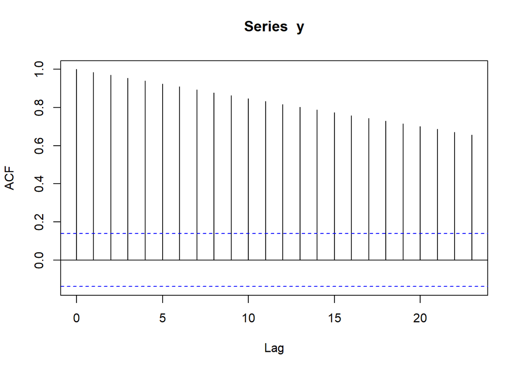

```r
#The autocorrelation function (ACF) can also be used to spot autocorrelation.
acf(y)
```

```r
#Same can be concluded by regressing a variable on its lagged self
summary(lm(lr$residuals[2:101]~lr$residuals[1:100]))
```

```
##
## Call:
## lm(formula = lr$residuals[2:101] ~ lr$residuals[1:100])
##
## Residuals:
##     Min      1Q  Median      3Q     Max
## -2.3913 -0.7529  0.0179  0.6161  3.3450
##
## Coefficients:
##                     Estimate Std. Error t value Pr(>|t|)
## (Intercept)         -0.01213    0.11022   -0.11    0.913
## lr$residuals[1:100]  0.83610    0.05538   15.10   <2e-16 ***
## ---
## Signif. codes:  0 '***' 0.001 '**' 0.01 '*' 0.05 '.' 0.1 ' ' 1
##
## Residual standard error: 1.101 on 98 degrees of freedom
## Multiple R-squared:  0.6993, Adjusted R-squared:  0.6963
## F-statistic: 227.9 on 1 and 98 DF,  p-value: < 2.2e-16
```

```r
#The consequence of autocorrelation is that the the results of the hypothesis tests can be unreliable. However the OLS coefficients are still unbiased, the estimators are consistent and yield accurate estimates for a large sample
lr<-lm(zt[2:251]~zt[1:250])

#Autocorrelation can be addressed in various way, most commonly by adding lag terms as done above. Autocorrelation will occur mostly in the context of time series.
```

### Time Series

We need to make a distinction in two types of data: - Cross-sectional data: Data on certain attributes collected at one point in time. - Time series data: Data on certain attributes collected on different (regular) points in time.

Time series pose certain challenges in making use of OLS. One of the possible issues, autocorrelation in data, was already discussed in the last section. Many time series, like for example in case of stock price returns, will be affected heavily by previous datapoints.

Additionally trends in the covariates and response in time series can easilly lead to spurrious regression if one is not careful. An example is given below.

```r
#Generate random walks
rw_1<-0
rw_2<-0

set.seed(1001)

for(i in 2:100){
  rw_1[i]<-rw_1[i-1]+rnorm(1)
  rw_2[i]<-rw_2[i-1]+rnorm(1)
}

#Perform a regression: Note that the regression slope coeffiecient is very significant while the two coefficients are not related. This is known as spurrious regression.
rw_fit<-(lm(rw_2~rw_1))
summary(rw_fit)
```

```
##
## Call:
## lm(formula = rw_2 ~ rw_1)
##
## Residuals:
##     Min      1Q  Median      3Q     Max
## -5.0563 -1.1803 -0.0321  1.1780  5.8793
##
## Coefficients:
##             Estimate Std. Error t value Pr(>|t|)
## (Intercept)  1.16505    0.24557   4.744 7.12e-06 ***
## rw_1        -0.70737    0.05197 -13.611  < 2e-16 ***
## ---
## Signif. codes:  0 '***' 0.001 '**' 0.01 '*' 0.05 '.' 0.1 ' ' 1
##
## Residual standard error: 1.977 on 98 degrees of freedom
## Multiple R-squared:  0.654,  Adjusted R-squared:  0.6505
## F-statistic: 185.3 on 1 and 98 DF,  p-value: < 2.2e-16
```

```r
#We shouldn't be explain the movements in the random walk with another variable, so how can show this in a regression? Now look what happens if we:
#1. Add a trend
summary(lm(diff(rw_2)~diff(rw_1)+seq(1,99)))
```

```
##
## Call:
## lm(formula = diff(rw_2) ~ diff(rw_1) + seq(1, 99))
##
## Residuals:
##     Min      1Q  Median      3Q     Max
## -2.5809 -0.6329  0.0296  0.6092  3.3470
##
## Coefficients:
##              Estimate Std. Error t value Pr(>|t|)
## (Intercept)  0.065473   0.202734   0.323    0.747
## diff(rw_1)  -0.049493   0.102584  -0.482    0.631
## seq(1, 99)  -0.000139   0.003521  -0.039    0.969
##
## Residual standard error: 1.001 on 96 degrees of freedom
## Multiple R-squared:  0.002427,   Adjusted R-squared:  -0.01836
## F-statistic: 0.1168 on 2 and 96 DF,  p-value: 0.8899
```

```r
#2. Take time differences in the variables (so that they become stationary, i.e. have the same distribution statistics over time)
summary(lm(diff(rw_2)~diff(rw_1)))
```

```
##
## Call:
## lm(formula = diff(rw_2) ~ diff(rw_1))
##
## Residuals:
##     Min      1Q  Median      3Q     Max
## -2.5742 -0.6290  0.0350  0.6052  3.3504
##
## Coefficients:
##             Estimate Std. Error t value Pr(>|t|)
## (Intercept)  0.05853    0.10033   0.583    0.561
## diff(rw_1)  -0.04939    0.10202  -0.484    0.629
##
## Residual standard error: 0.9957 on 97 degrees of freedom
## Multiple R-squared:  0.00241,    Adjusted R-squared:  -0.007874
## F-statistic: 0.2344 on 1 and 97 DF,  p-value: 0.6294
```

```r
#As the random walk is autoregegressive, adding a lag should yield a significant (OLS) coefficient.
summary(lm(rw_1[2:100]~rw_1[1:99]))
```

```
##
## Call:
## lm(formula = rw_1[2:100] ~ rw_1[1:99])
##
## Residuals:
##      Min       1Q   Median       3Q      Max
## -1.86860 -0.74229 -0.00317  0.54663  2.34181
##
## Coefficients:
##             Estimate Std. Error t value Pr(>|t|)
## (Intercept) -0.15316    0.12228  -1.253    0.213
## rw_1[1:99]   0.97010    0.02603  37.262   <2e-16 ***
## ---
## Signif. codes:  0 '***' 0.001 '**' 0.01 '*' 0.05 '.' 0.1 ' ' 1
##
## Residual standard error: 0.9843 on 97 degrees of freedom
## Multiple R-squared:  0.9347, Adjusted R-squared:  0.934
## F-statistic:  1388 on 1 and 97 DF,  p-value: < 2.2e-16
```

Time series models are a topic of there own as also can be seen from the example and will be discussed separately.

## Application of OLS on a dataset

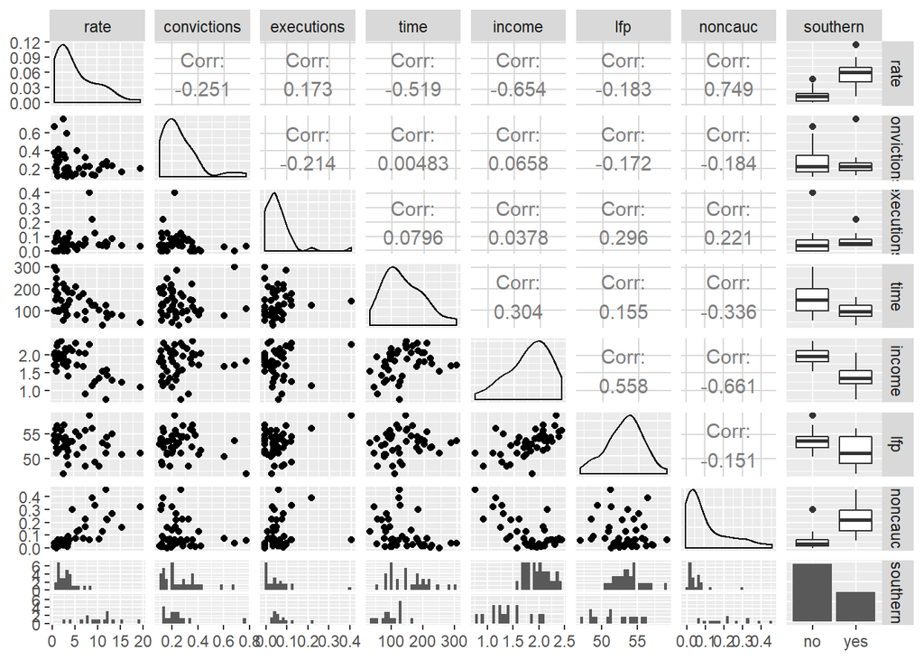

```r
require('AER')
require('zoo')
require('GGally')
data("MurderRates")

#Normally it is good to examine the data for outliers, however due to the smal dataset and as we want to focus on the regression analysis we will include all data in the dataset.

#Make a pairs plot to see relation in the data
#Note that there is a notable correlation between lfp and income, which can impact the bias/variance in the estimation depending on whether or not they are included.
ggpairs(MurderRates)
```

```r
#Full model
full_model<-lm(rate~.,data=MurderRates)
summary(full_model)
```

```
##
## Call:
## lm(formula = rate ~ ., data = MurderRates)
##
## Residuals:
##     Min      1Q  Median      3Q     Max
## -4.9913 -1.1943 -0.3538  1.2383  6.5574
##
## Coefficients:
##             Estimate Std. Error t value Pr(>|t|)
## (Intercept)  0.44436    9.96694   0.045   0.9647
## convictions -4.33938    2.78313  -1.559   0.1277
## executions   2.85276    6.12313   0.466   0.6441
## time        -0.01547    0.00705  -2.194   0.0348 *
## income      -2.50013    1.68519  -1.484   0.1466
## lfp          0.19357    0.20614   0.939   0.3540
## noncauc     10.39903    5.40610   1.924   0.0623 .
## southernyes  3.26216    1.32980   2.453   0.0191 *
## ---
## Signif. codes:  0 '***' 0.001 '**' 0.01 '*' 0.05 '.' 0.1 ' ' 1
##
## Residual standard error: 2.459 on 36 degrees of freedom
## Multiple R-squared:  0.7459, Adjusted R-squared:  0.6965
## F-statistic:  15.1 on 7 and 36 DF,  p-value: 5.105e-09
```

```r
#Null model
null_model<-lm(rate~1,data=MurderRates)

#Note that including new variables will always lead to a better fit (R^2), however we want to eliminate insignificant variables and obtain a 'parsimonious' and 'optimal' model that works as well on non-training data. There are different measures that can be optimized in order to obtain such an optimal model, like the Adjusted R^2, AIC or BIC. The step function does this in terms of the AIC.
#The step function can either start with the full model and optimize backward by dropping variables or start with an empty model and keep adding variables. We choose the option 'both' which examined both cases.
red_model<-step(full_model,direction ="both")
```

```
## Start:  AIC=86.35
## rate ~ convictions + executions + time + income + lfp + noncauc +
##     southern
##
##               Df Sum of Sq    RSS    AIC
## - executions   1     1.312 218.99 84.613
## - lfp          1     5.331 223.01 85.413
## <none>                     217.68 86.348
## - income       1    13.309 230.99 86.960
## - convictions  1    14.699 232.38 87.224
## - noncauc      1    22.373 240.05 88.653
## - time         1    29.113 246.79 89.872
## - southern     1    36.388 254.07 91.150
##
## Step:  AIC=84.61
## rate ~ convictions + time + income + lfp + noncauc + southern
##
##               Df Sum of Sq    RSS    AIC
## - lfp          1     7.006 226.00 83.999
## <none>                     218.99 84.613
## - income       1    12.666 231.66 85.087
## - convictions  1    16.056 235.05 85.726
## + executions   1     1.312 217.68 86.348
## - noncauc      1    25.037 244.03 87.376
## - time         1    27.856 246.85 87.881
## - southern     1    38.946 257.94 89.815
##
## Step:  AIC=84
## rate ~ convictions + time + income + noncauc + southern
##
##               Df Sum of Sq    RSS    AIC
## - income       1     6.369 232.37 83.222
## <none>                     226.00 83.999
## + lfp          1     7.006 218.99 84.613
## + executions   1     2.987 223.01 85.413
## - convictions  1    21.255 247.25 85.954
## - time         1    28.030 254.03 87.143
## - southern     1    35.330 261.33 88.390
## - noncauc      1    39.586 265.58 89.101
##
## Step:  AIC=83.22
## rate ~ convictions + time + noncauc + southern
##
##               Df Sum of Sq    RSS    AIC
## <none>                     232.37 83.222
## + income       1     6.369 226.00 83.999
## - convictions  1    20.420 252.79 84.928
## + executions   1     1.097 231.27 85.013
## + lfp          1     0.709 231.66 85.087
## - time         1    26.694 259.06 86.006
## - noncauc      1    57.408 289.77 90.936
## - southern     1    60.181 292.55 91.355
```

```r
summary(red_model)
```

```
##
## Call:
## lm(formula = rate ~ convictions + time + noncauc + southern,
##     data = MurderRates)
##
## Residuals:
##     Min      1Q  Median      3Q     Max
## -4.5200 -1.5375 -0.4578  1.4669  6.6747
##
## Coefficients:
##              Estimate Std. Error t value Pr(>|t|)
## (Intercept)  5.885154   1.434504   4.103 0.000201 ***
## convictions -4.974470   2.687056  -1.851 0.071714 .
## time        -0.014578   0.006887  -2.117 0.040723 *
## noncauc     14.520544   4.677909   3.104 0.003546 **
## southernyes  3.729056   1.173343   3.178 0.002899 **
## ---
## Signif. codes:  0 '***' 0.001 '**' 0.01 '*' 0.05 '.' 0.1 ' ' 1
##
## Residual standard error: 2.441 on 39 degrees of freedom
## Multiple R-squared:  0.7288, Adjusted R-squared:  0.7009
## F-statistic:  26.2 on 4 and 39 DF,  p-value: 1.357e-10
```

```r
require(stats)
AIC(red_model)
```

```
## [1] 210.0881
```